# Quem são os SNPs com p-valores altos?

Vitória

2023-04-11

## Quem são os SNPs com p-valores altos?

Conforme descrito no [primeiro relatório](https://github.com/VitoriaHorvathMiranda/ident_clinalSNPs/blob/main/relatorio_clinalSNP_ident.md), exitem muitos p-valores muito altos do primeiro call (aquele cuja a frequencia global mínima era de 0.5%). Quando fiz o segundo call, com frequência global mínima de 1%, a situação melhorou um pouco. Mas ainda era possível observar muitos p-valores muito altos.

Eu queria entender melhor quem eram esses SNPs com p-valores tão altos. Como o call era feito com todas populações juntas, independente do ano de amostra, esperavamos que a maioria desses SNPs representassem SNPs presentes em um período mas não no outro. Assim, no período no qual ele não estivesse presente, todas as populações amostradas teriam frequência igual a zero. Essa série de zeros claramente geraria p-valores muito altos. Visto isso, resolvi filtrar os SNPs cuja a frequência era igual a zero em todas as populações de cada uma das épocas amostradas (não tinha pensado em como fazer isso antes). Depois de filtrar esses SNPs, eu refiz os histogramas dos p-valores:

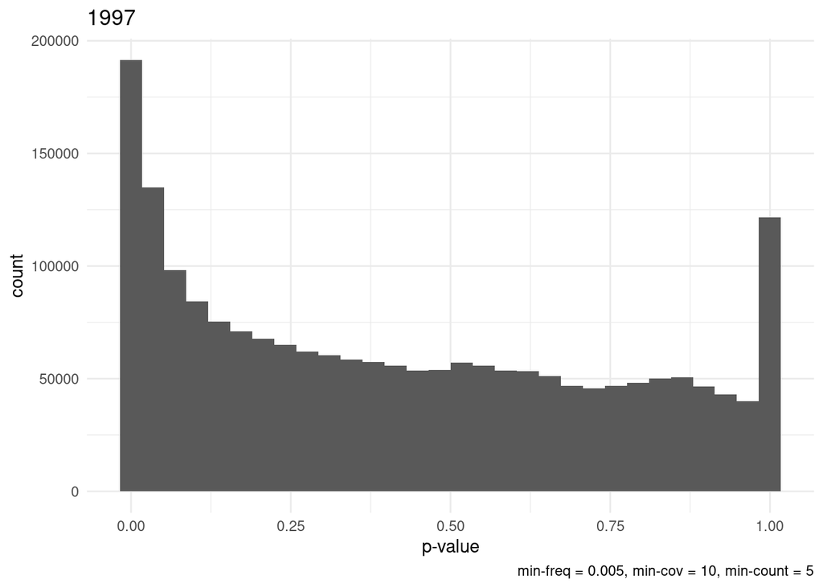

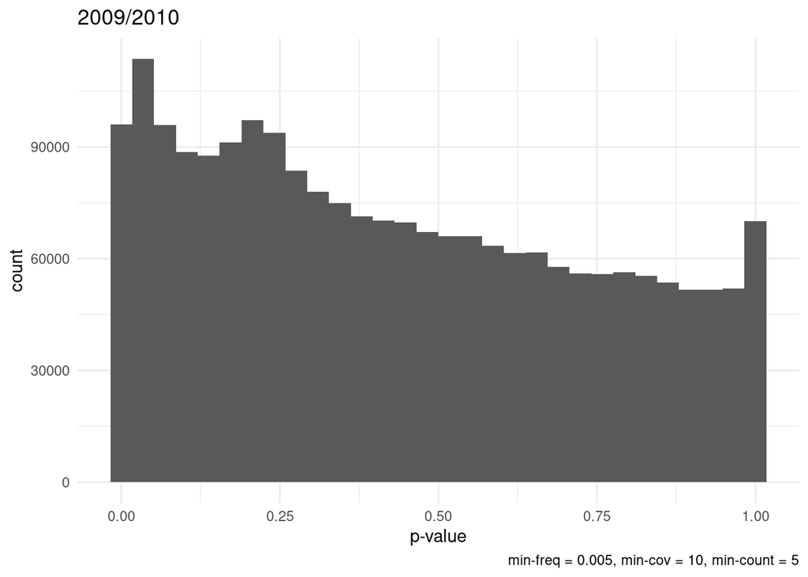

Embora a maioria dos p-valores altos desapareça depois desse filtro, ainda é possível ver o pico no extremo do gráfico. Então resolvi filtrar todos os SNPs cuja a frequência só era diferente de zero em uma população de um determinado período, ou seja, removi todos os SNPs unicos de uma determinada população. Quando fiz isso, os p-valores altos desaparesceram:

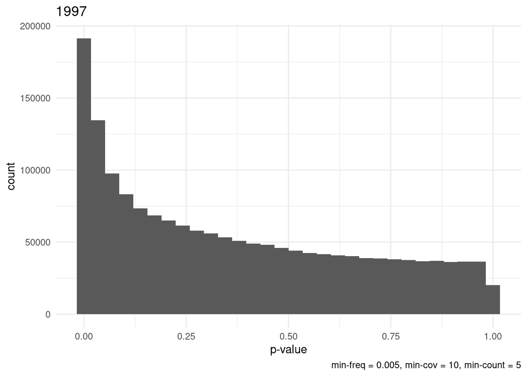

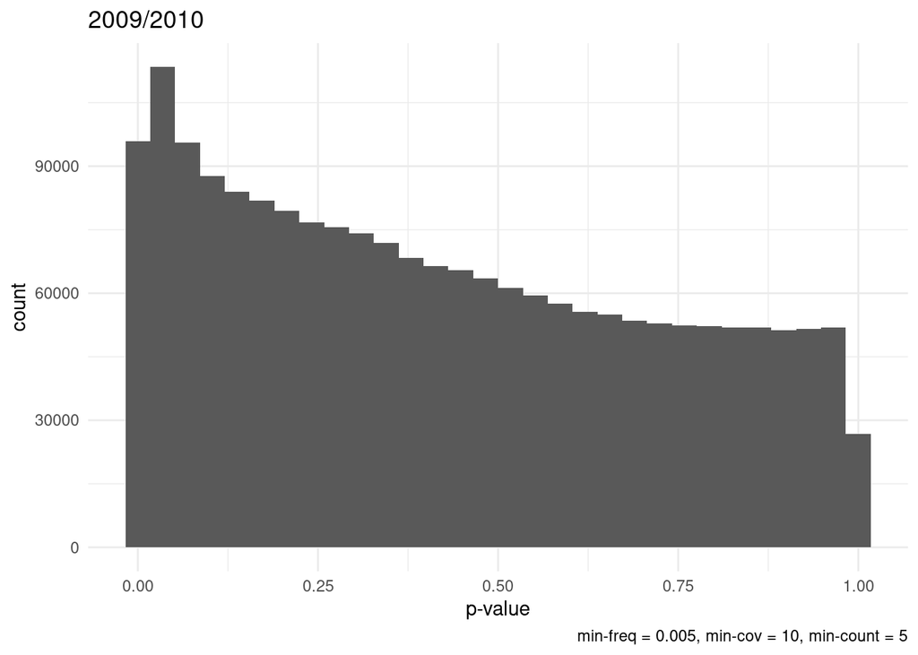

Dá para ver que a forma do histograma de 2009/2010 muda um pouco, acho que isso ocorre quando esses SNPs únicos estão presentes em populações nos extremos latitudinais. O histograma com apenas os SNPs removidos fica assim:

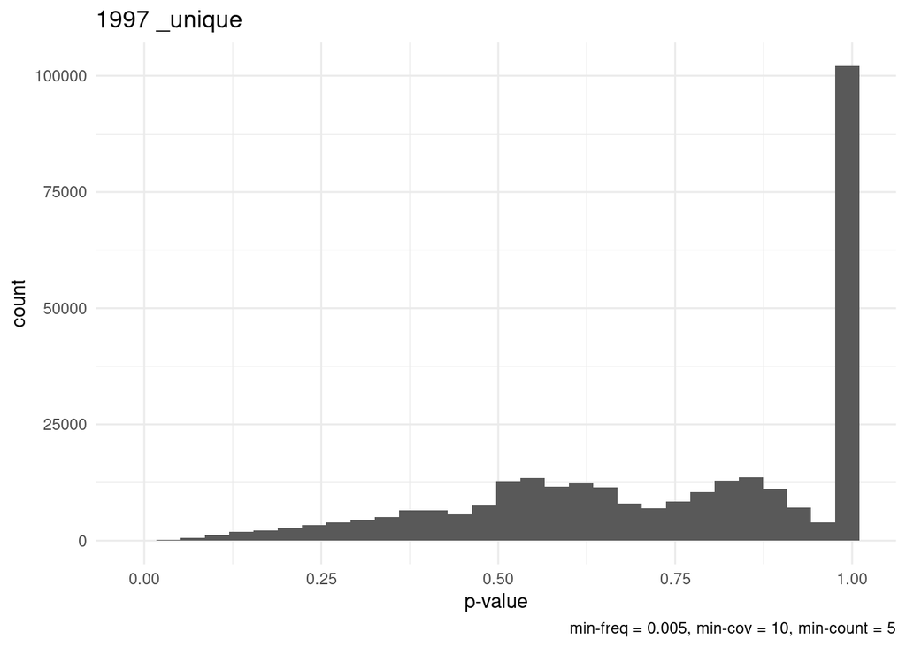

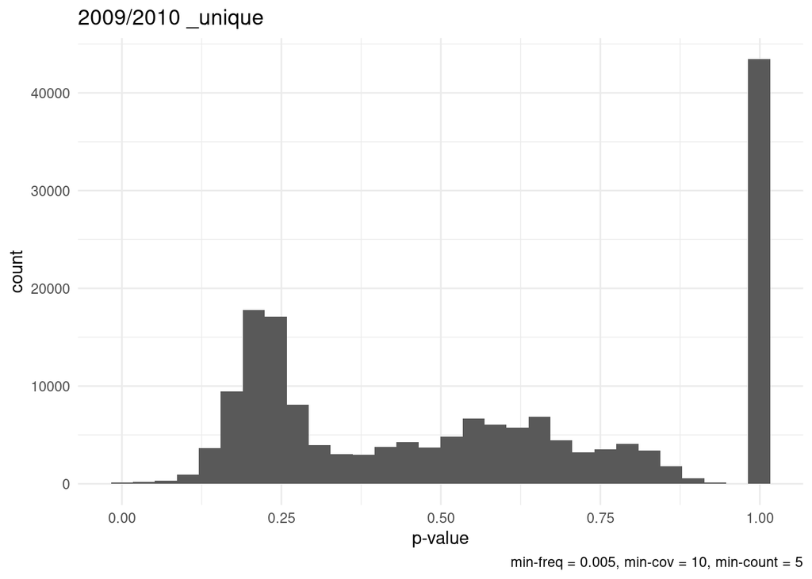

Como o segundo call (com frequência mínima de 1%) não havia removido completamente esse pico de SNPs altos, imaginei que pelo menos alguns deles tivessem frequências altas nas populações onde ocorrem, e aparentemente isso realmente ocorre:

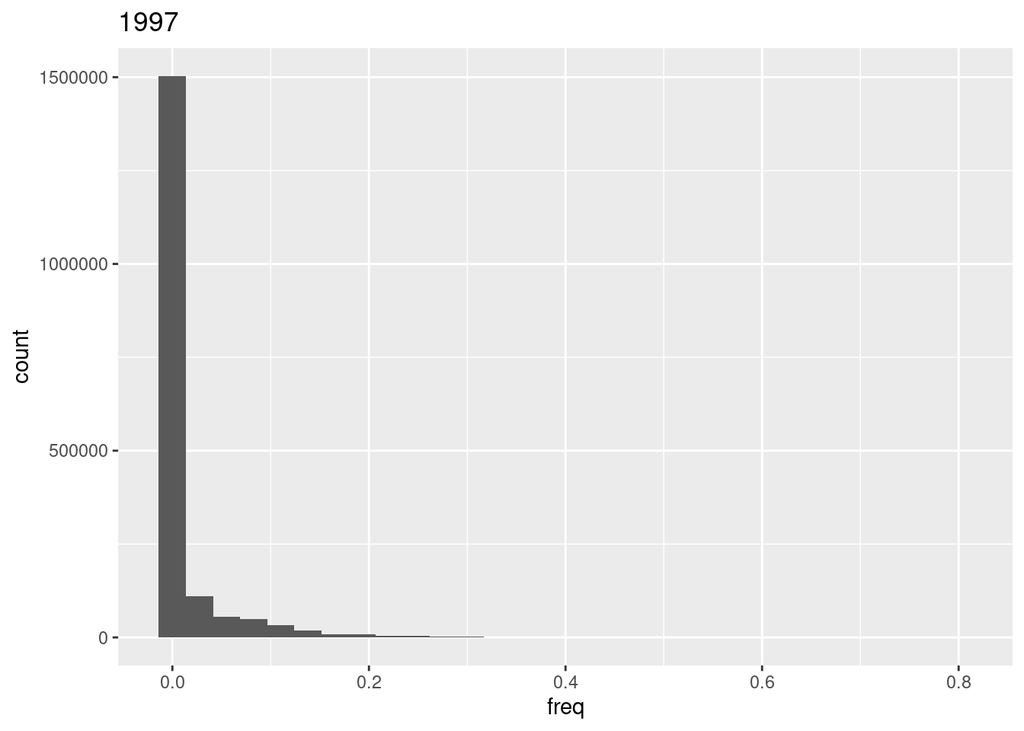

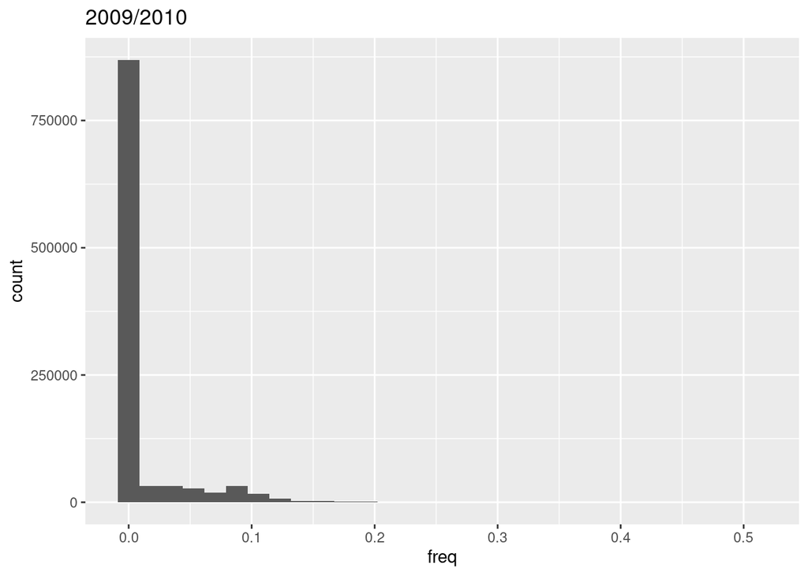

No final, dá para perceber que o pico de p-valores é causado principalmente pelos SNPs que parecem em apenas uma população:

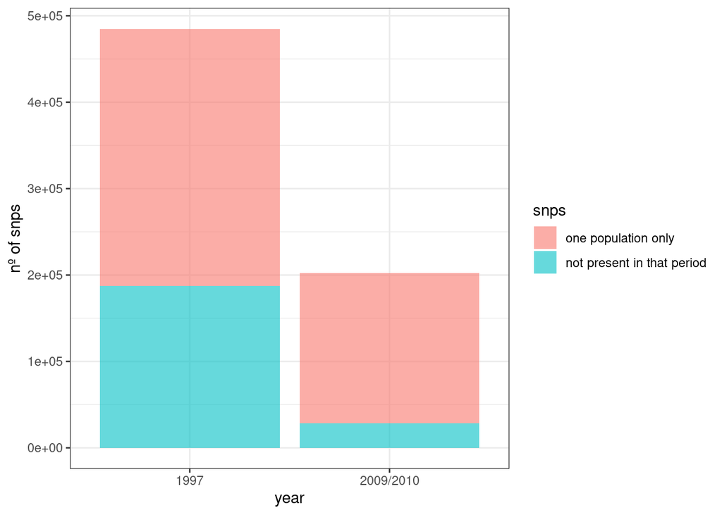

Dos SNPs presentes em apenas uma população, 49.722 estão presentes em ambos os períodos, mas desses, apenas 21.776 aparecem na mesma região geográfica. Como a maioria das coletas não ocorrem exatamente nos mesmos pontos nos dois períodos, separei os pontos de coleta em três grupos em relação a latitude. Latitude baixa, menor que 30; média, entre 30 e 40; e alta, maior que 40. Dos 21.776 SNPs únicos que aparecem na mesma região, 891 tiveram uma mudança de frequência maior que 0.2.